# FINAL EDA

MO SAHOR

04/25/2020

## INTRODUCTION

Entertainment is surrounding us in all directions of our lives and there is less to nothing we can do about it because we all love to be entertained. However, the most valued form of entertainment nowadays will undoubtedly be sports. There are various types of sporting events out there but without wasting much time we will like to dive in to the sport that motivated the cause of this analytical study, Soccer, specifically the Barclays Premier League (EPL) and their Referees. The EPL is the most watched soccer league in the world which makes it more interesting to study.

In the premier league, there are a lot of emotions involved, just like any other sport league, which puts a lot of pressure on the decision makers, in other words, the Referees. Referees have the power to shift the energy of the game from moderate to tense or vise versa with a single decision made. The decision could either be right or wrong but no one cares as long as they are not the victim against the referee’s decision. Therefore, we will like to analyze one of the major decisions faced by referee which is giving out red cards, to send a player off the field for at least 2 games, by asking the question, which referee gave out the most red card and what’s his probability of giving out a red card?

There is always this dilemma surrounding referees from soccer fans that they have a hard time winning with certain referees when playing away from home and others like to say that certain referees only favor home teams when playing. Home crowd can have a huge impact on a referee’s decisions during a game and can sometimes interfere with the end result of the game. In my second analysis, I investigated this by trying to answer the question, do home or away teams have more chances of winning a game with certain referees?

## DATA

The data for this analysis is a collection of different data from the 2017/2018 English Premier League’s season. The data was collected from http://www.football-data.co.uk/ by Christian Rønsholt and then uploaded to Kaggle.

The original data from Christian Rønsholt has many variables. Almost all the statistics found in every soccer game for that particular season could be found there as it was used to help the people that bet on sports to make a better decision on their betting. However, my aim is to help coaches predict referees decisions in games. Therefore, out of all those data, only a few were used in evaluating and further investigate the questions. Four variables were used in total, 3 for the first question and 2 for the second question. The names of the variables used for the first question were the Referee, Home red card (HR) and Away red card (AR) and for the second question, the Referee and Full Time Result (FTR) variables were used.

| Referee | HR | AR | FTR |
| --- | --- | --- | --- |
| M Dean | 0 | 0 | H |
| M Oliver | 0 | 0 | A |
| C Pawson | 2 | 0 | A |
| J Moss | 0 | 0 | A |
| N Swarbrick | 0 | 0 | H |
| M Jones | 0 | 0 | D |

In the table above, the referee column shows the referee that was responsible for a specific game played that day between a home and away team. In order to evaluate the decisions referees make, I needed to include the referee column to represent the names of each referee. The HR and AR represents the number of home red cards and away red cards each referee gave out during the game they were assigned to. HR and AR will help us gather the data we need to answer the question, which referee gave out the most red card and what’s his probability of giving out a red card? Finally FTR column shows full time results of each game with ‘A’ in a cell meaning that the away team won that game, ’H’ meaning the home team won the game and ‘D’ meaning that the game was a tie. The FTR info will help us to answer the second question, do home/away teams have more chances of winning the game with certain referees?

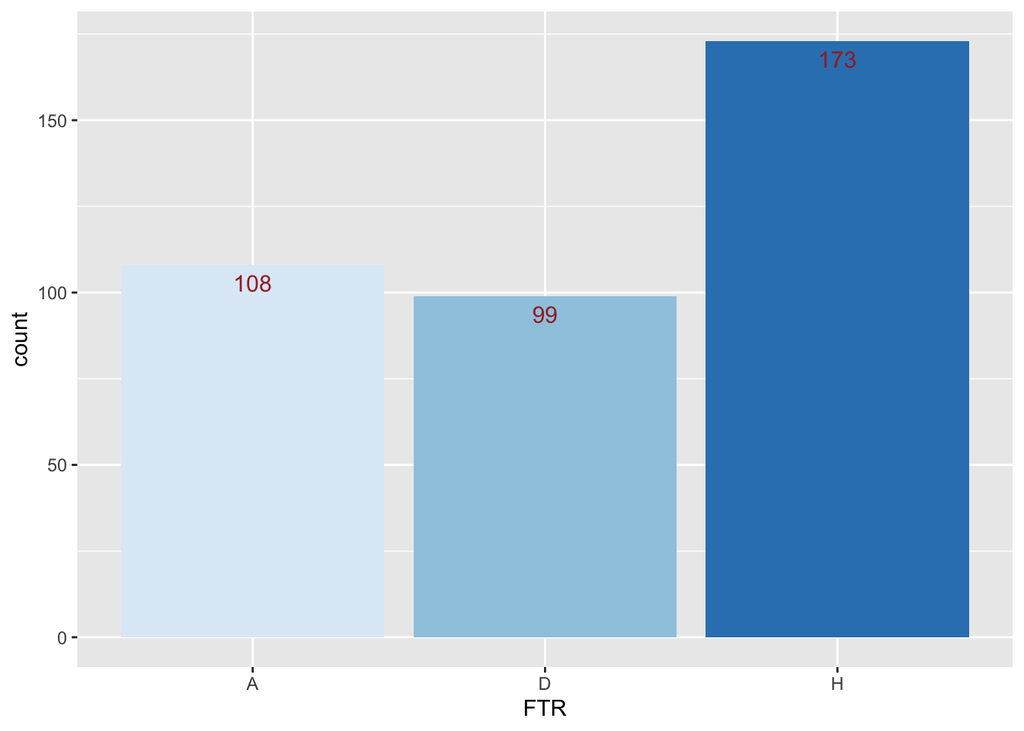

## RESULT

Question 1.

| Referee | HR | AR | totalRed |
| --- | --- | --- | --- |
| M Dean | 0 | 0 | 0 |
| M Oliver | 0 | 0 | 0 |
| C Pawson | 2 | 0 | 2 |
| J Moss | 0 | 0 | 0 |
| N Swarbrick | 0 | 0 | 0 |
| M Jones | 0 | 0 | 0 |

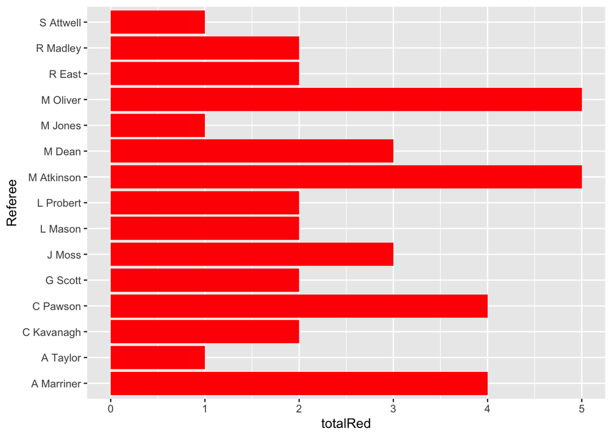

Question 2.

For the second question, trying to know if home or away teams have more chances of winning a game with certain referees. I filtered the original data by selecting the needed columns which are the Referee and Full Time Result columns to have all the information ready for visualization.

Referee

|  | A | D | H |
| --- | --- | --- | --- |
| A Marriner | 10 | 4 | 14 |
| A Taylor | 6 | 9 | 12 |
| C Kavanagh | 5 | 3 | 7 |
| C Pawson | 5 | 4 | 15 |
| D Coote | 1 | 0 | 0 |
| G Scott | 6 | 3 | 11 |
| J Moss | 11 | 10 | 8 |
| K Friend | 2 | 5 | 14 |
| L Mason | 5 | 4 | 9 |
| L Probert | 6 | 3 | 5 |
| M Atkinson | 11 | 7 | 10 |
| M Dean | 7 | 7 | 11 |
| M Jones | 2 | 3 | 7 |
| M Oliver | 11 | 10 | 9 |
| N Swarbrick | 6 | 3 | 11 |
| P Tierney | 5 | 3 | 8 |
| R East | 3 | 7 | 8 |
| R Madley | 4 | 7 | 7 |
| S Attwell | 2 | 6 | 7 |
| S Hooper | 0 | 1 | 0 |

In the figure above, it shows each referee with their various full time results in a single game. However, the chart below displays their counts in each of the variables, the green bar representing a tie game (D), the red bar representing away wins (A) and blue representing home wins (H) for each referee. We want to know which referee is most likely to contain the pressure in a home game to the point that an away team might stand a chance of winning without being a victim of bad decision making, and which might be falling for the manipulation of the home crowd and make more decision in their favor.

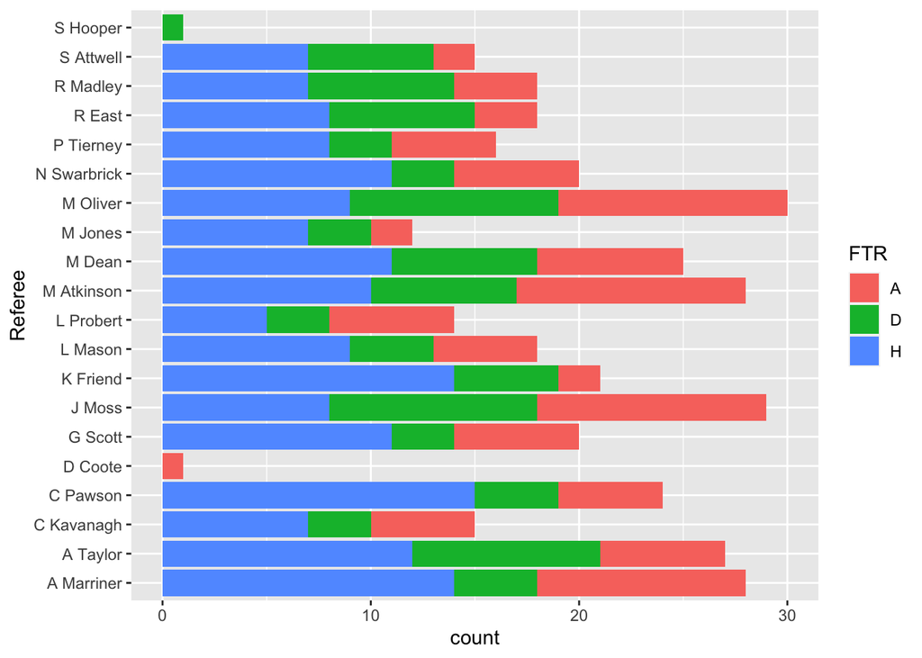

By analyzing the data, Away teams have more wins with J. Moss, M. Oliver, M. Atkinson, D. Coote and L. Probert and Home teams have more wins with the other referees. The result shows that away teams stand higher chance of winning with a handful of referees even though they are playing against the pressure of the home crowd. But there are more referees with home games being won.

## CONCLUSION

We wanted to find out which referee gave out the most red cards and what’s his probability of giving out a red card. And we found that some referees do give out more red cards in a game than other referees and that observation could be used to help the coaches determine which referees they should watch out for to not get on there bad side during the game. Another question we had was do home or away teams have more chances of winning a game with certain referees. The results favored homes teams more than away teams in the observation. Meaning there are more referees that would feel comfortable with the points, at the end of a game, going to the home team rather than the away team. But there are certain referees whom away coaches could feel more confident about to walk away with the points.

However, referees might have other incidents that causes them to give out more red cards than other referees in certain games in that season since we are only looking at one season out of many. There might have been some reckless plays made by players that gives the referee no chance but to give out a red card. Also this analysis of referees is not the only factor that contributes to home teams having higher chance of winning a game. Factors like playing on a home ground gives players extra motivation to go out and play well with the support of their home crowd. Therefore to gain more knowledge of referees and how often they give red cards, one might want to study more league seasons. Of home or away teams having more chances of winning a game with certain referees, one might want to also look at other factors held by the various team — if some teams have a good home or away record, or are certain teams better than others.